# Spotify Playlist Explorer

Marie Le Bars

21 mai 2016

# Presentation

This is a personal project to practice on Coursera Data Science Specialization. Here I used the Spotify API with the [spotifyr package](https://github.com/rweyant/spotifyr) to build plots on my playlist.

```r
# Loading spotifyr and its (many) dependencies.
library("spotifyr")

# Packages version from sessionInfo() :
# > sessionInfo()
# R version 3.2.4 Revised (2016-03-16 r70336)
# Platform: x86_64-w64-mingw32/x64 (64-bit)
# Running under: Windows >= 8 x64 (build 9200)
#
# locale:
# [1] LC_COLLATE=French_France.1252  LC_CTYPE=French_France.1252    LC_MONETARY=French_France.1252
# [4] LC_NUMERIC=C                   LC_TIME=French_France.1252
#
# attached base packages:
# [1] stats     graphics  grDevices utils     datasets  methods   base
#
# other attached packages:
#  [1] spotifyr_0.1    plyr_1.8.3      stringi_1.0-1   stringr_1.0.0   RSelenium_1.3.5 XML_3.98-1.4    RJSONIO_1.3-0
#  [8] RCurl_1.95-4.8  bitops_1.0-6    jsonlite_0.9.20 httr_1.1.0
#
# loaded via a namespace (and not attached):
#  [1] Rcpp_0.12.5     digest_0.6.9    R6_2.1.2        magrittr_1.5    curl_0.9.7      rmarkdown_0.9.6 tools_3.2.4
#  [8] yaml_2.1.13     caTools_1.17.1  htmltools_0.3.5 knitr_1.13
```

First I registered an application on [Spotify API](https://developer.spotify.com/my-applications) where I obtained credentials. These credentials have been saved in the variables spotifyCID, spotifySecret and spotifyRedirect (not echo’d). I also saved my UserID and PlaylistID under the variables spotifyUser and spotifyPlaylist (also not echo’d).

The spotifyr provides function to authenticate (and refresh if needed) with the spotify API:

```r
set_credentials(client_id=spotifyCID,client_secret=spotifySecret,client_redirect_uri=spotifyRedirect)
client_tokens <- get_tokens()
user_code <- get_user_code()
user_tokens <- get_user_token(user_code)
```

```r
refresh_tokens <- refresh_user_token()
# refresh_tokens <- refresh_user_token(user_tokens$refresh_token)
```

Now I can start importing my playlist. Spotify API only allows to import 100 tracks at a time so the function below will use the offset parameter to import batches of 100 tracks until the playlist is complete.

```r
startPlaylist <- get_playlist_tracks(user_id=spotifyUser,playlist_id=spotifyPlaylist)

if (startPlaylist$total > 100) {
  total <- startPlaylist
  numOffset <- trunc(startPlaylist$total/100)
  for(i in 1:numOffset) {
    subPlaylist <- get_playlist_tracks(user_id=spotifyUser,playlist_id=spotifyPlaylist, offset=(i*100))
    total <- mapply(c, total, subPlaylist, SIMPLIFY=FALSE)
  }
} else {
  total <- startPlaylist
}
```

The output of get playlist tracks is a list. The subsets are then merged in a global list stored under the variable total.  
Next for ease of read I’ll build a dataframe to store for each track the title of the song, the artist’s name, the album’s name and the year of release.

```r
playlistDataFrame <- data.frame()
for(i in 1:length(total$items)) {
  playlistDataFrame[i,1] <- total$items[[i]]$track$name
  playlistDataFrame[i,2] <- total$items[[i]]$track$artists[[1]]$name
  playlistDataFrame[i,3] <- total$items[[i]]$track$album$name
  playlistDataFrame[i,4] <- as.numeric(substr(get_album(total$items[[i]]$track$album$id)$release_date, 1, 4))
}

names(playlistDataFrame) <- c("Title", "Artist", "Album", "Release Date")
```

With the new dataframe I can see which year is most represented, and how many different artists and albums are in the playlist.

```r
dateFreq <- count(playlistDataFrame[,4])
maxFreq <- max(dateFreq$freq)
topYear <- dateFreq[dateFreq$freq==maxFreq,]$x
uniqueArtists <- length(unique(playlistDataFrame$Artist))
uniqueAlbums <- length(unique(playlistDataFrame$Album))
```

The most popular year was 2005 with 24 songs. There are 158 different artists and 219 different albums in this playlist.  
Let’s have a look at how many songs per release year are in this playlist:

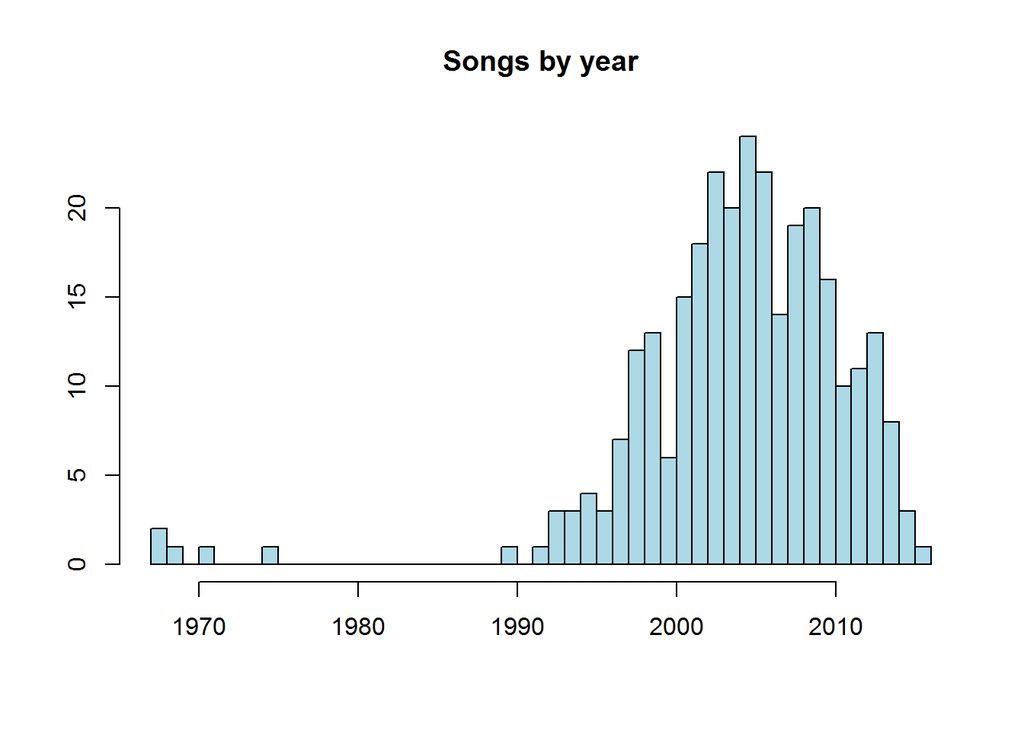